# PROJECT: Wrangling and Analyze Data

TABLE OF CONTENTS

Data Gathering

Assessing Data

Quality Issues

Tidiness issues

Analyzing and Visualizing Data

# Data Gathering

```python
#import all packages

import pandas as pd
import requests
import tweepy
import numpy as np
from tweepy import OAuthHandler
import json
from timeit import default_timer as timer
import matplotlib.pyplot as plt
```

```python
# load twitter-archive-enhanced.csv

twitter_archive= pd.read_csv('twitter-archive-enhanced.csv')
twitter_archive.head()
```

|  | tweet_id | in_reply_to_status_id | in_reply_to_user_id | timestamp | source | text | retweeted_status_id | retweeted_status_user_id | retweeted_status_timestamp | expanded_urls | rating_numerator | rating_denominator | name | doggo | floofer | pupper | puppo |
| --- | --- | --- | --- | --- | --- | --- | --- | --- | --- | --- | --- | --- | --- | --- | --- | --- | --- |
| 0 | 892420643555336193 | NaN | NaN | 2017-08-01 16:23:56 +0000 | <a href="http://twitter.com/download/iphone" r... | This is Phineas. He's a mystical boy. Only eve... | NaN | NaN | NaN | https://twitter.com/dog_rates/status/892420643... | 13 | 10 | Phineas | None | None | None | None |
| 1 | 892177421306343426 | NaN | NaN | 2017-08-01 00:17:27 +0000 | <a href="http://twitter.com/download/iphone" r... | This is Tilly. She's just checking pup on you.... | NaN | NaN | NaN | https://twitter.com/dog_rates/status/892177421... | 13 | 10 | Tilly | None | None | None | None |
| 2 | 891815181378084864 | NaN | NaN | 2017-07-31 00:18:03 +0000 | <a href="http://twitter.com/download/iphone" r... | This is Archie. He is a rare Norwegian Pouncin... | NaN | NaN | NaN | https://twitter.com/dog_rates/status/891815181... | 12 | 10 | Archie | None | None | None | None |
| 3 | 891689557279858688 | NaN | NaN | 2017-07-30 15:58:51 +0000 | <a href="http://twitter.com/download/iphone" r... | This is Darla. She commenced a snooze mid meal... | NaN | NaN | NaN | https://twitter.com/dog_rates/status/891689557... | 13 | 10 | Darla | None | None | None | None |
| 4 | 891327558926688256 | NaN | NaN | 2017-07-29 16:00:24 +0000 | <a href="http://twitter.com/download/iphone" r... | This is Franklin. He would like you to stop ca... | NaN | NaN | NaN | https://twitter.com/dog_rates/status/891327558... | 12 | 10 | Franklin | None | None | None | None |

```python
#Use request to access tweet image predictions(image-predictions.tsv)

url='https://d17h27t6h515a5.cloudfront.net/topher/2017/August/599fd2ad_image-predictions/image-predictions.tsv'
tweet_image=requests.get(url)
tweet_image
```

```
<Response [200]>
```

```python
with open('image-predictions.tsv', 'wb') as file:
    file.write(tweet_image.content)
```

```python
image_predictions=pd.read_csv('image-predictions.tsv', sep='\t')
image_predictions
```

|  | tweet_id | jpg_url | img_num | p1 | p1_conf | p1_dog | p2 | p2_conf | p2_dog | p3 | p3_conf | p3_dog |
| --- | --- | --- | --- | --- | --- | --- | --- | --- | --- | --- | --- | --- |
| 0 | 666020888022790149 | https://pbs.twimg.com/media/CT4udn0WwAA0aMy.jpg | 1 | Welsh_springer_spaniel | 0.465074 | True | collie | 0.156665 | True | Shetland_sheepdog | 0.061428 | True |
| 1 | 666029285002620928 | https://pbs.twimg.com/media/CT42GRgUYAA5iDo.jpg | 1 | redbone | 0.506826 | True | miniature_pinscher | 0.074192 | True | Rhodesian_ridgeback | 0.072010 | True |
| 2 | 666033412701032449 | https://pbs.twimg.com/media/CT4521TWwAEvMyu.jpg | 1 | German_shepherd | 0.596461 | True | malinois | 0.138584 | True | bloodhound | 0.116197 | True |
| 3 | 666044226329800704 | https://pbs.twimg.com/media/CT5Dr8HUEAA-lEu.jpg | 1 | Rhodesian_ridgeback | 0.408143 | True | redbone | 0.360687 | True | miniature_pinscher | 0.222752 | True |
| 4 | 666049248165822465 | https://pbs.twimg.com/media/CT5IQmsXIAAKY4A.jpg | 1 | miniature_pinscher | 0.560311 | True | Rottweiler | 0.243682 | True | Doberman | 0.154629 | True |
| ... | ... | ... | ... | ... | ... | ... | ... | ... | ... | ... | ... | ... |
| 2070 | 891327558926688256 | https://pbs.twimg.com/media/DF6hr6BUMAAzZgT.jpg | 2 | basset | 0.555712 | True | English_springer | 0.225770 | True | German_short-haired_pointer | 0.175219 | True |
| 2071 | 891689557279858688 | https://pbs.twimg.com/media/DF_q7IAWsAEuuN8.jpg | 1 | paper_towel | 0.170278 | False | Labrador_retriever | 0.168086 | True | spatula | 0.040836 | False |
| 2072 | 891815181378084864 | https://pbs.twimg.com/media/DGBdLU1WsAANxJ9.jpg | 1 | Chihuahua | 0.716012 | True | malamute | 0.078253 | True | kelpie | 0.031379 | True |
| 2073 | 892177421306343426 | https://pbs.twimg.com/media/DGGmoV4XsAAUL6n.jpg | 1 | Chihuahua | 0.323581 | True | Pekinese | 0.090647 | True | papillon | 0.068957 | True |
| 2074 | 892420643555336193 | https://pbs.twimg.com/media/DGKD1-bXoAAIAUK.jpg | 1 | orange | 0.097049 | False | bagel | 0.085851 | False | banana | 0.076110 | False |

2075 rows × 12 columns

```python
#Use Twitter keys and tokens to access twitter

consumer_key = 'YOUR CONSUMER KEY'
consumer_secret = 'YOUR CONSUMER SECRET'
access_token = 'YOUR ACCESS TOKEN'
access_secret = 'YOUR ACCESS SECRET'

auth = tweepy.OAuthHandler(consumer_key, consumer_secret)
auth.set_access_token(access_token, access_secret)

api = tweepy.API(auth)
```

```python
#Query Twitter's API for JSON data for each tweet ID in the Twitter archive

'''count = 0
fails_dict = {}
start = timer()
# Save each tweet's returned JSON as a new line in a .txt file
with open('tweet_json.txt', 'w') as outfile:
    # This loop will likely take 20-30 minutes to run because of Twitter's rate limit
    for tweet_id in tweet_ids:
        count += 1
        print(str(count) + ": " + str(tweet_id))
        try:
            tweet = api.get_status(tweet_id, tweet_mode='extended')
            print("Success")
            json.dump(tweet._json, outfile)
            outfile.write('\n')
        except tweepy.errors.TweepyException as e:
            print("Fail")
            fails_dict[tweet_id] = e
            pass
end = timer()
print(end - start)
print(fails_dict)''';
```

```python
# creating a list to read the twee_json.txt into

tweet_list=[]
with open('tweet_json.txt') as f:
    for line in f:
        tweet_id=json.loads(line)['id']
        favorite_count=json.loads(line)['favorite_count']
        retweet_count=json.loads(line)['retweet_count']

        tweet_list.append({'tweet_id':tweet_id,
                         'favorite_count': favorite_count,
                         'retweet_count': retweet_count})

# Convert the Dictionary to DataFrame
tweet_df=pd.DataFrame(tweet_list, columns=['tweet_id', 'favorite_count', 'retweet_count'])
```

```python
tweet_df.head()
```

|  | tweet_id | favorite_count | retweet_count |
| --- | --- | --- | --- |
| 0 | 892420643555336193 | 39467 | 8853 |
| 1 | 892177421306343426 | 33819 | 6514 |
| 2 | 891815181378084864 | 25461 | 4328 |
| 3 | 891689557279858688 | 42908 | 8964 |
| 4 | 891327558926688256 | 41048 | 9774 |

## ASSESSING DATA

This section involves visual and programatic assessment of the datasets gathered. Quality and tidyness issues are detected and reported.

### VISUAL ASSESSMENT

```python
twitter_archive
```

|  | tweet_id | in_reply_to_status_id | in_reply_to_user_id | timestamp | source | text | retweeted_status_id | retweeted_status_user_id | retweeted_status_timestamp | expanded_urls | rating_numerator | rating_denominator | name | doggo | floofer | pupper | puppo |
| --- | --- | --- | --- | --- | --- | --- | --- | --- | --- | --- | --- | --- | --- | --- | --- | --- | --- |
| 0 | 892420643555336193 | NaN | NaN | 2017-08-01 16:23:56 +0000 | <a href="http://twitter.com/download/iphone" r... | This is Phineas. He's a mystical boy. Only eve... | NaN | NaN | NaN | https://twitter.com/dog_rates/status/892420643... | 13 | 10 | Phineas | None | None | None | None |
| 1 | 892177421306343426 | NaN | NaN | 2017-08-01 00:17:27 +0000 | <a href="http://twitter.com/download/iphone" r... | This is Tilly. She's just checking pup on you.... | NaN | NaN | NaN | https://twitter.com/dog_rates/status/892177421... | 13 | 10 | Tilly | None | None | None | None |
| 2 | 891815181378084864 | NaN | NaN | 2017-07-31 00:18:03 +0000 | <a href="http://twitter.com/download/iphone" r... | This is Archie. He is a rare Norwegian Pouncin... | NaN | NaN | NaN | https://twitter.com/dog_rates/status/891815181... | 12 | 10 | Archie | None | None | None | None |
| 3 | 891689557279858688 | NaN | NaN | 2017-07-30 15:58:51 +0000 | <a href="http://twitter.com/download/iphone" r... | This is Darla. She commenced a snooze mid meal... | NaN | NaN | NaN | https://twitter.com/dog_rates/status/891689557... | 13 | 10 | Darla | None | None | None | None |
| 4 | 891327558926688256 | NaN | NaN | 2017-07-29 16:00:24 +0000 | <a href="http://twitter.com/download/iphone" r... | This is Franklin. He would like you to stop ca... | NaN | NaN | NaN | https://twitter.com/dog_rates/status/891327558... | 12 | 10 | Franklin | None | None | None | None |
| ... | ... | ... | ... | ... | ... | ... | ... | ... | ... | ... | ... | ... | ... | ... | ... | ... | ... |
| 2351 | 666049248165822465 | NaN | NaN | 2015-11-16 00:24:50 +0000 | <a href="http://twitter.com/download/iphone" r... | Here we have a 1949 1st generation vulpix. Enj... | NaN | NaN | NaN | https://twitter.com/dog_rates/status/666049248... | 5 | 10 | None | None | None | None | None |
| 2352 | 666044226329800704 | NaN | NaN | 2015-11-16 00:04:52 +0000 | <a href="http://twitter.com/download/iphone" r... | This is a purebred Piers Morgan. Loves to Netf... | NaN | NaN | NaN | https://twitter.com/dog_rates/status/666044226... | 6 | 10 | a | None | None | None | None |
| 2353 | 666033412701032449 | NaN | NaN | 2015-11-15 23:21:54 +0000 | <a href="http://twitter.com/download/iphone" r... | Here is a very happy pup. Big fan of well-main... | NaN | NaN | NaN | https://twitter.com/dog_rates/status/666033412... | 9 | 10 | a | None | None | None | None |
| 2354 | 666029285002620928 | NaN | NaN | 2015-11-15 23:05:30 +0000 | <a href="http://twitter.com/download/iphone" r... | This is a western brown Mitsubishi terrier. Up... | NaN | NaN | NaN | https://twitter.com/dog_rates/status/666029285... | 7 | 10 | a | None | None | None | None |
| 2355 | 666020888022790149 | NaN | NaN | 2015-11-15 22:32:08 +0000 | <a href="http://twitter.com/download/iphone" r... | Here we have a Japanese Irish Setter. Lost eye... | NaN | NaN | NaN | https://twitter.com/dog_rates/status/666020888... | 8 | 10 | None | None | None | None | None |

2356 rows × 17 columns

```python
image_predictions
```

|  | tweet_id | jpg_url | img_num | p1 | p1_conf | p1_dog | p2 | p2_conf | p2_dog | p3 | p3_conf | p3_dog |
| --- | --- | --- | --- | --- | --- | --- | --- | --- | --- | --- | --- | --- |
| 0 | 666020888022790149 | https://pbs.twimg.com/media/CT4udn0WwAA0aMy.jpg | 1 | Welsh_springer_spaniel | 0.465074 | True | collie | 0.156665 | True | Shetland_sheepdog | 0.061428 | True |
| 1 | 666029285002620928 | https://pbs.twimg.com/media/CT42GRgUYAA5iDo.jpg | 1 | redbone | 0.506826 | True | miniature_pinscher | 0.074192 | True | Rhodesian_ridgeback | 0.072010 | True |
| 2 | 666033412701032449 | https://pbs.twimg.com/media/CT4521TWwAEvMyu.jpg | 1 | German_shepherd | 0.596461 | True | malinois | 0.138584 | True | bloodhound | 0.116197 | True |
| 3 | 666044226329800704 | https://pbs.twimg.com/media/CT5Dr8HUEAA-lEu.jpg | 1 | Rhodesian_ridgeback | 0.408143 | True | redbone | 0.360687 | True | miniature_pinscher | 0.222752 | True |
| 4 | 666049248165822465 | https://pbs.twimg.com/media/CT5IQmsXIAAKY4A.jpg | 1 | miniature_pinscher | 0.560311 | True | Rottweiler | 0.243682 | True | Doberman | 0.154629 | True |
| ... | ... | ... | ... | ... | ... | ... | ... | ... | ... | ... | ... | ... |
| 2070 | 891327558926688256 | https://pbs.twimg.com/media/DF6hr6BUMAAzZgT.jpg | 2 | basset | 0.555712 | True | English_springer | 0.225770 | True | German_short-haired_pointer | 0.175219 | True |
| 2071 | 891689557279858688 | https://pbs.twimg.com/media/DF_q7IAWsAEuuN8.jpg | 1 | paper_towel | 0.170278 | False | Labrador_retriever | 0.168086 | True | spatula | 0.040836 | False |
| 2072 | 891815181378084864 | https://pbs.twimg.com/media/DGBdLU1WsAANxJ9.jpg | 1 | Chihuahua | 0.716012 | True | malamute | 0.078253 | True | kelpie | 0.031379 | True |
| 2073 | 892177421306343426 | https://pbs.twimg.com/media/DGGmoV4XsAAUL6n.jpg | 1 | Chihuahua | 0.323581 | True | Pekinese | 0.090647 | True | papillon | 0.068957 | True |
| 2074 | 892420643555336193 | https://pbs.twimg.com/media/DGKD1-bXoAAIAUK.jpg | 1 | orange | 0.097049 | False | bagel | 0.085851 | False | banana | 0.076110 | False |

2075 rows × 12 columns

```python
tweet_df
```

|  | tweet_id | favorite_count | retweet_count |
| --- | --- | --- | --- |
| 0 | 892420643555336193 | 39467 | 8853 |
| 1 | 892177421306343426 | 33819 | 6514 |
| 2 | 891815181378084864 | 25461 | 4328 |
| 3 | 891689557279858688 | 42908 | 8964 |
| 4 | 891327558926688256 | 41048 | 9774 |
| ... | ... | ... | ... |
| 2349 | 666049248165822465 | 111 | 41 |
| 2350 | 666044226329800704 | 311 | 147 |
| 2351 | 666033412701032449 | 128 | 47 |
| 2352 | 666029285002620928 | 132 | 48 |
| 2353 | 666020888022790149 | 2535 | 532 |

2354 rows × 3 columns

### PROGRAMMATIC ASSESSMENT

This section would be with the use of codes to assess the datsets to ceck to any quality or tidiness issue.

#### TWITTER ARCHIVE

```python
# This shows information about the columns in the dataset- Name of Columns, Number of non-null values and datatypes of column data

twitter_archive.info()
```

```
<class 'pandas.core.frame.DataFrame'>
RangeIndex: 2356 entries, 0 to 2355
Data columns (total 17 columns):
 #   Column                      Non-Null Count  Dtype
---  ------                      --------------  -----
 0   tweet_id                    2356 non-null   int64
 1   in_reply_to_status_id       78 non-null     float64
 2   in_reply_to_user_id         78 non-null     float64
 3   timestamp                   2356 non-null   object
 4   source                      2356 non-null   object
 5   text                        2356 non-null   object
 6   retweeted_status_id         181 non-null    float64
 7   retweeted_status_user_id    181 non-null    float64
 8   retweeted_status_timestamp  181 non-null    object
 9   expanded_urls               2297 non-null   object
 10  rating_numerator            2356 non-null   int64
 11  rating_denominator          2356 non-null   int64
 12  name                        2356 non-null   object
 13  doggo                       2356 non-null   object
 14  floofer                     2356 non-null   object
 15  pupper                      2356 non-null   object
 16  puppo                       2356 non-null   object
dtypes: float64(4), int64(3), object(10)
memory usage: 313.0+ KB
```

From the above information:

There are missing values in some columns

Tweet_id and timestamp have the wrong datatype

The dog stages are on different columns which is wrong

```python
sum(twitter_archive.duplicated())
```

```
0
```

This shows that there is no duplicated row in the dataset.

```python
twitter_archive.rating_denominator.value_counts()
```

```
10     2333
11        3
50        3
20        2
80        2
70        1
7         1
15        1
150       1
170       1
0         1
90        1
40        1
130       1
110       1
16        1
120       1
2         1
Name: rating_denominator, dtype: int64
```

```python
twitter_archive.rating_numerator.value_counts()
```

```
12      558
11      464
10      461
13      351
9       158
8       102
7        55
14       54
5        37
6        32
3        19
4        17
2         9
1         9
75        2
```

[output cut: 26 more lines]

```python
twitter_archive.source.value_counts()
```

```
<a href="http://twitter.com/download/iphone" rel="nofollow">Twitter for iPhone</a>     2221
<a href="http://vine.co" rel="nofollow">Vine - Make a Scene</a>                          91
<a href="http://twitter.com" rel="nofollow">Twitter Web Client</a>                       33
<a href="https://about.twitter.com/products/tweetdeck" rel="nofollow">TweetDeck</a>      11
Name: source, dtype: int64
```

This gives information about different sources the twitter archive dataset was gotten from

```python
twitter_archive.name.unique()
```

```
array(['Phineas', 'Tilly', 'Archie', 'Darla', 'Franklin', 'None', 'Jax',
       'Zoey', 'Cassie', 'Koda', 'Bruno', 'Ted', 'Stuart', 'Oliver',
       'Jim', 'Zeke', 'Ralphus', 'Canela', 'Gerald', 'Jeffrey', 'such',
       'Maya', 'Mingus', 'Derek', 'Roscoe', 'Waffles', 'Jimbo', 'Maisey',
       'Lilly', 'Earl', 'Lola', 'Kevin', 'Yogi', 'Noah', 'Bella',
       'Grizzwald', 'Rusty', 'Gus', 'Stanley', 'Alfy', 'Koko', 'Rey',
       'Gary', 'a', 'Elliot', 'Louis', 'Jesse', 'Romeo', 'Bailey',
       'Duddles', 'Jack', 'Emmy', 'Steven', 'Beau', 'Snoopy', 'Shadow',
       'Terrance', 'Aja', 'Penny', 'Dante', 'Nelly', 'Ginger', 'Benedict',
       'Venti', 'Goose', 'Nugget', 'Cash', 'Coco', 'Jed', 'Sebastian',
       'Walter', 'Sierra', 'Monkey', 'Harry', 'Kody', 'Lassie', 'Rover',
       'Napolean', 'Dawn', 'Boomer', 'Cody', 'Rumble', 'Clifford',
       'quite', 'Dewey', 'Scout', 'Gizmo', 'Cooper', 'Harold', 'Shikha',
       'Jamesy', 'Lili', 'Sammy', 'Meatball', 'Paisley', 'Albus',
       'Neptune', 'Quinn', 'Belle', 'Zooey', 'Dave', 'Jersey', 'Hobbes',
       'Burt', 'Lorenzo', 'Carl', 'Jordy', 'Milky', 'Trooper', 'Winston',
       'Sophie', 'Wyatt', 'Rosie', 'Thor', 'Oscar', 'Luna', 'Callie',
       'Cermet', 'George', 'Marlee', 'Arya', 'Einstein', 'Alice',
       'Rumpole', 'Benny', 'Aspen', 'Jarod', 'Wiggles', 'General',
       'Sailor', 'Astrid', 'Iggy', 'Snoop', 'Kyle', 'Leo', 'Riley',
       'Gidget', 'Noosh', 'Odin', 'Jerry', 'Charlie', 'Georgie', 'Rontu',
       'Cannon', 'Furzey', 'Daisy', 'Tuck', 'Barney', 'Vixen', 'Jarvis',
       'Mimosa', 'Pickles', 'Bungalo', 'Brady', 'Margo', 'Sadie', 'Hank',
       'Tycho', 'Stephan', 'Indie', 'Winnie', 'Bentley', 'Ken', 'Max',
       'Maddie', 'Pipsy', 'Monty', 'Sojourner', 'Odie', 'Arlo', 'Sunny',
       'Vincent', 'Lucy', 'Clark', 'Mookie', 'Meera', 'Buddy', 'Ava',
       'Rory', 'Eli', 'Ash', 'Tucker', 'Tobi', 'Chester', 'Wilson',
       'Sunshine', 'Lipton', 'Gabby', 'Bronte', 'Poppy', 'Rhino',
       'Willow', 'not', 'Orion', 'Eevee', 'Smiley', 'Logan', 'Moreton',
       'Klein', 'Miguel', 'Emanuel', 'Kuyu', 'Dutch', 'Pete', 'Scooter',
       'Reggie', 'Kyro', 'Samson', 'Loki', 'Mia', 'Malcolm', 'Dexter',
       'Alfie', 'Fiona', 'one', 'Mutt', 'Bear', 'Doobert', 'Beebop',
       'Alexander', 'Sailer', 'Brutus', 'Kona', 'Boots', 'Ralphie',
       'Phil', 'Cupid', 'Pawnd', 'Pilot', 'Ike', 'Mo', 'Toby', 'Sweet',
       'Pablo', 'Nala', 'Balto', 'Crawford', 'Gabe', 'Mattie', 'Jimison',
       'Hercules', 'Duchess', 'Harlso', 'Sampson', 'Sundance', 'Luca',
       'Flash', 'Finn', 'Peaches', 'Howie', 'Jazzy', 'Anna', 'Bo',
       'Seamus', 'Wafer', 'Chelsea', 'Tom', 'Moose', 'Florence', 'Autumn',
       'Dido', 'Eugene', 'Herschel', 'Strudel', 'Tebow', 'Chloe', 'Betty',
       'Timber', 'Binky', 'Dudley', 'Comet', 'Larry', 'Levi', 'Akumi',
```

[output cut: 88 more lines]

```
       'Anthony', 'Holly', 'Jett', 'Amy', 'Sage', 'Andy', 'Mason',
       'Trigger', 'Antony', 'Creg', 'Traviss', 'Gin', 'Jeffrie', 'Danny',
       'Ester', 'Pluto', 'Bloo', 'Edd', 'Willy', 'Herb', 'Damon',
       'Peanut', 'Nigel', 'Butters', 'Sandra', 'Fabio', 'Randall', 'Liam',
       'Tommy', 'Ben', 'Raphael', 'Julio', 'Andru', 'Kloey', 'Shawwn',
       'Skye', 'Kollin', 'Ronduh', 'Billl', 'Saydee', 'Dug', 'Tessa',
       'Sully', 'Kirk', 'Ralf', 'Clarq', 'Jaspers', 'Samsom', 'Harrison',
       'Chaz', 'Jeremy', 'Jaycob', 'Lambeau', 'Ruffles', 'Amélie', 'Bobb',
       'Banditt', 'Kevon', 'Winifred', 'Hanz', 'Churlie', 'Zeek',
       'Timofy', 'Maks', 'Jomathan', 'Kallie', 'Marvin', 'Spark',
       'Gòrdón', 'Jo', 'DayZ', 'Jareld', 'Torque', 'Ron', 'Skittles',
       'Cleopatricia', 'Erik', 'Stu', 'Tedrick', 'Filup', 'Kial',
       'Naphaniel', 'Dook', 'Hall', 'Philippe', 'Biden', 'Fwed',
       'Genevieve', 'Joshwa', 'Bradlay', 'Clybe', 'Keet', 'Carll',
       'Jockson', 'Josep', 'Lugan', 'Christoper'], dtype=object)
```

There are odd names like 'a' and 'an'

```python
twitter_archive['name'].value_counts()
```

```
None          745
a              55
Charlie        12
Cooper         11
Lucy           11
             ...
Dex             1
Ace             1
Tayzie          1
Grizzie         1
Christoper      1
Name: name, Length: 957, dtype: int64
```

```python
twitter_archive.describe()
```

|  | tweet_id | in_reply_to_status_id | in_reply_to_user_id | retweeted_status_id | retweeted_status_user_id | rating_numerator | rating_denominator |
| --- | --- | --- | --- | --- | --- | --- | --- |
| count | 2.356000e+03 | 7.800000e+01 | 7.800000e+01 | 1.810000e+02 | 1.810000e+02 | 2356.000000 | 2356.000000 |
| mean | 7.427716e+17 | 7.455079e+17 | 2.014171e+16 | 7.720400e+17 | 1.241698e+16 | 13.126486 | 10.455433 |
| std | 6.856705e+16 | 7.582492e+16 | 1.252797e+17 | 6.236928e+16 | 9.599254e+16 | 45.876648 | 6.745237 |
| min | 6.660209e+17 | 6.658147e+17 | 1.185634e+07 | 6.661041e+17 | 7.832140e+05 | 0.000000 | 0.000000 |
| 25% | 6.783989e+17 | 6.757419e+17 | 3.086374e+08 | 7.186315e+17 | 4.196984e+09 | 10.000000 | 10.000000 |
| 50% | 7.196279e+17 | 7.038708e+17 | 4.196984e+09 | 7.804657e+17 | 4.196984e+09 | 11.000000 | 10.000000 |
| 75% | 7.993373e+17 | 8.257804e+17 | 4.196984e+09 | 8.203146e+17 | 4.196984e+09 | 12.000000 | 10.000000 |
| max | 8.924206e+17 | 8.862664e+17 | 8.405479e+17 | 8.874740e+17 | 7.874618e+17 | 1776.000000 | 170.000000 |

#### IMAGE PREDICTIONS

```python
image_predictions.info()
```

```
<class 'pandas.core.frame.DataFrame'>
RangeIndex: 2075 entries, 0 to 2074
Data columns (total 12 columns):
 #   Column    Non-Null Count  Dtype
---  ------    --------------  -----
 0   tweet_id  2075 non-null   int64
 1   jpg_url   2075 non-null   object
 2   img_num   2075 non-null   int64
 3   p1        2075 non-null   object
 4   p1_conf   2075 non-null   float64
 5   p1_dog    2075 non-null   bool
 6   p2        2075 non-null   object
 7   p2_conf   2075 non-null   float64
 8   p2_dog    2075 non-null   bool
 9   p3        2075 non-null   object
 10  p3_conf   2075 non-null   float64
 11  p3_dog    2075 non-null   bool
dtypes: bool(3), float64(3), int64(2), object(4)
memory usage: 152.1+ KB
```

tweet_id should be in strings not integer

```python
sum(image_predictions.duplicated())
```

```
0
```

This shows there is no duplicate in the dataset

```python
image_predictions.img_num.value_counts()
```

```
1    1780
2     198
3      66
4      31
Name: img_num, dtype: int64
```

```python
image_predictions.p1.value_counts()
```

```
golden_retriever      150
Labrador_retriever    100
Pembroke               89
Chihuahua              83
pug                    57
                     ...
pillow                  1
carousel                1
bald_eagle              1
lorikeet                1
orange                  1
Name: p1, Length: 378, dtype: int64
```

```python
image_predictions.p2.value_counts()
```

```
Labrador_retriever    104
golden_retriever       92
Cardigan               73
Chihuahua              44
Pomeranian             42
                     ...
medicine_chest          1
quail                   1
horse_cart              1
waffle_iron             1
bagel                   1
Name: p2, Length: 405, dtype: int64
```

```python
image_predictions.p3.value_counts()
```

```
Labrador_retriever    79
Chihuahua             58
golden_retriever      48
Eskimo_dog            38
kelpie                35
                      ..
ox                     1
assault_rifle          1
axolotl                1
pot                    1
banana                 1
Name: p3, Length: 408, dtype: int64
```

```python
sum(image_predictions.jpg_url.duplicated())
```

```
66
```

#### TWEET DF

```python
tweet_df.info()
```

```
<class 'pandas.core.frame.DataFrame'>
RangeIndex: 2354 entries, 0 to 2353
Data columns (total 3 columns):
 #   Column          Non-Null Count  Dtype
---  ------          --------------  -----
 0   tweet_id        2354 non-null   int64
 1   favorite_count  2354 non-null   int64
 2   retweet_count   2354 non-null   int64
dtypes: int64(3)
memory usage: 55.3 KB
```

```python
sum(tweet_df.duplicated())
```

```
0
```

There is no duplicate row in this dataset

```python
tweet_df.describe()
```

|  | tweet_id | favorite_count | retweet_count |
| --- | --- | --- | --- |
| count | 2.354000e+03 | 2354.000000 | 2354.000000 |
| mean | 7.426978e+17 | 8080.968564 | 3164.797366 |
| std | 6.852812e+16 | 11814.771334 | 5284.770364 |
| min | 6.660209e+17 | 0.000000 | 0.000000 |
| 25% | 6.783975e+17 | 1415.000000 | 624.500000 |
| 50% | 7.194596e+17 | 3603.500000 | 1473.500000 |
| 75% | 7.993058e+17 | 10122.250000 | 3652.000000 |
| max | 8.924206e+17 | 132810.000000 | 79515.000000 |

### Quality issues

TWITTER ARCHIVE

1. Keep original tweets i.e tweets with images
1. Twitter_archive has some datas with 'retweet' which is not needed
1. Some unnecessary columns are in the dataset
1. Source column has wrong format
1. Timestamp with wrong datatype
1. Error in name coulumn
1. Error in rating_denominator column

IMAGE PREDICTIONS

1. Duplicates in jpg_url columns

### Tidiness issues

1. One variable(dog stage) in four columns(doggo, floofer, pupper,puppo) Irrelevant columns
1. Merge all datset into one column
1. Merge rating denominator and rating numerator column together

## CLEANING SECTION

QUALITY 1

define

First of all, keep all copies of the original datsets

code

```python
# use copy to keep clean copies of the three dataset

clean_twitter_archive= twitter_archive.copy()
clean_image_predictions= image_predictions.copy()
clean_tweet_df= tweet_df.copy()
```

QUALITY 2

define

Delete all rows with retweet that has no image in the tweet i.e both the retweeted_status_id and in_reply_to_user_id

code

```python
clean_twitter_archive=clean_twitter_archive[clean_twitter_archive.retweeted_status_id.isnull()]
clean_twitter_archive=clean_twitter_archive[clean_twitter_archive.in_reply_to_user_id.isnull()]
clean_twitter_archive=clean_twitter_archive
```

test

```python
clean_twitter_archive.info()
```

```
<class 'pandas.core.frame.DataFrame'>
Int64Index: 2097 entries, 0 to 2355
Data columns (total 17 columns):
 #   Column                      Non-Null Count  Dtype
---  ------                      --------------  -----
 0   tweet_id                    2097 non-null   int64
 1   in_reply_to_status_id       0 non-null      float64
 2   in_reply_to_user_id         0 non-null      float64
 3   timestamp                   2097 non-null   object
 4   source                      2097 non-null   object
 5   text                        2097 non-null   object
 6   retweeted_status_id         0 non-null      float64
 7   retweeted_status_user_id    0 non-null      float64
 8   retweeted_status_timestamp  0 non-null      object
 9   expanded_urls               2094 non-null   object
 10  rating_numerator            2097 non-null   int64
 11  rating_denominator          2097 non-null   int64
 12  name                        2097 non-null   object
 13  doggo                       2097 non-null   object
 14  floofer                     2097 non-null   object
 15  pupper                      2097 non-null   object
 16  puppo                       2097 non-null   object
dtypes: float64(4), int64(3), object(10)
memory usage: 294.9+ KB
```

QUALITY 3

define

Drop unnecessary columns

code

```python
clean_twitter_archive.drop(['in_reply_to_status_id','in_reply_to_user_id','retweeted_status_id',
                                            'retweeted_status_user_id','retweeted_status_timestamp', 'expanded_urls'],axis=1,inplace=True)
```

test

```python
clean_twitter_archive.info()
```

```
<class 'pandas.core.frame.DataFrame'>
Int64Index: 2097 entries, 0 to 2355
Data columns (total 11 columns):
 #   Column              Non-Null Count  Dtype
---  ------              --------------  -----
 0   tweet_id            2097 non-null   int64
 1   timestamp           2097 non-null   object
 2   source              2097 non-null   object
 3   text                2097 non-null   object
 4   rating_numerator    2097 non-null   int64
 5   rating_denominator  2097 non-null   int64
 6   name                2097 non-null   object
 7   doggo               2097 non-null   object
 8   floofer             2097 non-null   object
 9   pupper              2097 non-null   object
 10  puppo               2097 non-null   object
dtypes: int64(3), object(8)
memory usage: 196.6+ KB
```

QUALITY 4

define

code

```python
clean_twitter_archive.source.str.extract('>([\w\W\s]*)<',expand=True)
```

|  | 0 |
| --- | --- |
| 0 | Twitter for iPhone |
| 1 | Twitter for iPhone |
| 2 | Twitter for iPhone |
| 3 | Twitter for iPhone |
| 4 | Twitter for iPhone |
| ... | ... |
| 2351 | Twitter for iPhone |
| 2352 | Twitter for iPhone |
| 2353 | Twitter for iPhone |
| 2354 | Twitter for iPhone |
| 2355 | Twitter for iPhone |

2097 rows × 1 columns

test

```python
clean_twitter_archive.source.value_counts()
```

```
<a href="http://twitter.com/download/iphone" rel="nofollow">Twitter for iPhone</a>     1964
<a href="http://vine.co" rel="nofollow">Vine - Make a Scene</a>                          91
<a href="http://twitter.com" rel="nofollow">Twitter Web Client</a>                       31
<a href="https://about.twitter.com/products/tweetdeck" rel="nofollow">TweetDeck</a>      11
Name: source, dtype: int64
```

QUALITY 5

define

Correct wrong datatype

code

```python
# Change timestamp dtype to Datetime

clean_twitter_archive['timestamp']=pd.to_datetime(clean_twitter_archive['timestamp'])
```

test

```python
clean_twitter_archive.info()
```

```
<class 'pandas.core.frame.DataFrame'>
Int64Index: 2097 entries, 0 to 2355
Data columns (total 11 columns):
 #   Column              Non-Null Count  Dtype
---  ------              --------------  -----
 0   tweet_id            2097 non-null   int64
 1   timestamp           2097 non-null   datetime64[ns, UTC]
 2   source              2097 non-null   object
 3   text                2097 non-null   object
 4   rating_numerator    2097 non-null   int64
 5   rating_denominator  2097 non-null   int64
 6   name                2097 non-null   object
 7   doggo               2097 non-null   object
 8   floofer             2097 non-null   object
 9   pupper              2097 non-null   object
 10  puppo               2097 non-null   object
dtypes: datetime64[ns, UTC](1), int64(3), object(7)
memory usage: 196.6+ KB
```

QUALITY 6

define

Convert any name with 'a' or 'an' to None

code

```python
clean_twitter_archive['name'][clean_twitter_archive['name'].str.match('[a-z]+')] = 'None'
```

test

```python
clean_twitter_archive.name.value_counts()
```

```
None          707
Lucy           11
Charlie        11
Oliver         10
Cooper         10
             ...
Shelby          1
Sephie          1
Bonaparte       1
Wishes          1
Christoper      1
Name: name, Length: 930, dtype: int64
```

QUALITY 7

define

correct errors in rating_denominator

code

```python
clean_twitter_archive= clean_twitter_archive.query('rating_denominator>=10')
```

test

```python
clean_twitter_archive.rating_denominator.value_counts()
```

```
10     2080
50        3
11        2
80        2
70        1
150       1
170       1
20        1
90        1
40        1
110       1
120       1
Name: rating_denominator, dtype: int64
```

QUALITY 8

define

drop all duplicates in jpg_url column

code

```python
clean_image_predictions=clean_image_predictions.drop_duplicates(subset='jpg_url',keep="first")
```

test

```python
clean_image_predictions.jpg_url.duplicated().sum()
```

```
0
```

TIDINESS 1

define

code

```python
clean_twitter_archive.doggo.replace('None',"",inplace=True)
clean_twitter_archive.floofer.replace('None',"",inplace=True)
clean_twitter_archive.puppo.replace('None',"",inplace=True)
clean_twitter_archive.pupper.replace('None',"",inplace=True)

#merge columns dog_breed together
clean_twitter_archive ['dog_stage']=clean_twitter_archive.doggo +clean_twitter_archive.floofer +clean_twitter_archive.puppo +clean_twitter_archive.pupper
```

```python
# View stages


clean_twitter_archive.loc[clean_twitter_archive.dog_stage=='doggopupper','dog_stage']='doggo,pupper'
clean_twitter_archive.loc[clean_twitter_archive.dog_stage=='doggofloofer','dog_stage']='doggo,floofer'
clean_twitter_archive.loc[clean_twitter_archive.dog_stage=='doggopuppo','dog_stage']='doggo,puppo'
```

```python
# drop doggo, floofer, puppo and pupper

clean_twitter_archive.drop(['doggo','floofer','puppo','pupper'],axis=1,inplace=True)
```

```python
clean_twitter_archive.info()
```

```
<class 'pandas.core.frame.DataFrame'>
Int64Index: 2095 entries, 0 to 2355
Data columns (total 8 columns):
 #   Column              Non-Null Count  Dtype
---  ------              --------------  -----
 0   tweet_id            2095 non-null   int64
 1   timestamp           2095 non-null   datetime64[ns, UTC]
 2   source              2095 non-null   object
 3   text                2095 non-null   object
 4   rating_numerator    2095 non-null   int64
 5   rating_denominator  2095 non-null   int64
 6   name                2095 non-null   object
 7   dog_stage           2095 non-null   object
dtypes: datetime64[ns, UTC](1), int64(3), object(4)
memory usage: 147.3+ KB
```

TIDINESS 2

define

Merge all dataset into one dataframe

code

```python
combined=pd.merge(clean_twitter_archive,clean_image_predictions,on=['tweet_id'])
```

```python
#verify the merging of the first two datset sets

combined.info()
```

```
<class 'pandas.core.frame.DataFrame'>
Int64Index: 1969 entries, 0 to 1968
Data columns (total 19 columns):
 #   Column              Non-Null Count  Dtype
---  ------              --------------  -----
 0   tweet_id            1969 non-null   int64
 1   timestamp           1969 non-null   datetime64[ns, UTC]
 2   source              1969 non-null   object
 3   text                1969 non-null   object
 4   rating_numerator    1969 non-null   int64
 5   rating_denominator  1969 non-null   int64
 6   name                1969 non-null   object
 7   dog_stage           1969 non-null   object
 8   jpg_url             1969 non-null   object
 9   img_num             1969 non-null   int64
 10  p1                  1969 non-null   object
 11  p1_conf             1969 non-null   float64
 12  p1_dog              1969 non-null   bool
 13  p2                  1969 non-null   object
 14  p2_conf             1969 non-null   float64
 15  p2_dog              1969 non-null   bool
 16  p3                  1969 non-null   object
 17  p3_conf             1969 non-null   float64
 18  p3_dog              1969 non-null   bool
dtypes: bool(3), datetime64[ns, UTC](1), float64(3), int64(4), object(8)
memory usage: 267.3+ KB
```

```python
combined_df=pd.merge(combined,clean_tweet_df,on=['tweet_id'])
```

test

```python
combined_df.info()
```

```
<class 'pandas.core.frame.DataFrame'>
Int64Index: 1969 entries, 0 to 1968
Data columns (total 21 columns):
 #   Column              Non-Null Count  Dtype
---  ------              --------------  -----
 0   tweet_id            1969 non-null   int64
 1   timestamp           1969 non-null   datetime64[ns, UTC]
 2   source              1969 non-null   object
 3   text                1969 non-null   object
 4   rating_numerator    1969 non-null   int64
 5   rating_denominator  1969 non-null   int64
 6   name                1969 non-null   object
 7   dog_stage           1969 non-null   object
 8   jpg_url             1969 non-null   object
 9   img_num             1969 non-null   int64
 10  p1                  1969 non-null   object
 11  p1_conf             1969 non-null   float64
 12  p1_dog              1969 non-null   bool
 13  p2                  1969 non-null   object
 14  p2_conf             1969 non-null   float64
 15  p2_dog              1969 non-null   bool
 16  p3                  1969 non-null   object
 17  p3_conf             1969 non-null   float64
 18  p3_dog              1969 non-null   bool
 19  favorite_count      1969 non-null   int64
 20  retweet_count       1969 non-null   int64
dtypes: bool(3), datetime64[ns, UTC](1), float64(3), int64(6), object(8)
memory usage: 298.0+ KB
```

TIDINESS 3

define

Merge rating_numerator and rating_denominator to ratings

code

```python
combined_df['rating']=combined_df['rating_numerator']/combined_df['rating_denominator']
```

test

```python
combined_df.rating.value_counts()
```

```
1.200000      450
1.000000      419
1.100000      397
1.300000      253
0.900000      150
0.800000       95
0.700000       51
0.500000       33
1.400000       33
0.600000       32
0.300000       19
0.400000       15
0.200000       10
0.100000        4
0.000000        1
7.500000        1
2.700000        1
177.600000      1
0.818182        1
0.636364        1
2.600000        1
42.000000       1
Name: rating, dtype: int64
```

```python
combined_df.info()
```

```
<class 'pandas.core.frame.DataFrame'>
Int64Index: 1969 entries, 0 to 1968
Data columns (total 22 columns):
 #   Column              Non-Null Count  Dtype
---  ------              --------------  -----
 0   tweet_id            1969 non-null   int64
 1   timestamp           1969 non-null   datetime64[ns, UTC]
 2   source              1969 non-null   object
 3   text                1969 non-null   object
 4   rating_numerator    1969 non-null   int64
 5   rating_denominator  1969 non-null   int64
 6   name                1969 non-null   object
 7   dog_stage           1969 non-null   object
 8   jpg_url             1969 non-null   object
 9   img_num             1969 non-null   int64
 10  p1                  1969 non-null   object
 11  p1_conf             1969 non-null   float64
 12  p1_dog              1969 non-null   bool
 13  p2                  1969 non-null   object
 14  p2_conf             1969 non-null   float64
 15  p2_dog              1969 non-null   bool
 16  p3                  1969 non-null   object
 17  p3_conf             1969 non-null   float64
 18  p3_dog              1969 non-null   bool
 19  favorite_count      1969 non-null   int64
 20  retweet_count       1969 non-null   int64
 21  rating              1969 non-null   float64
dtypes: bool(3), datetime64[ns, UTC](1), float64(4), int64(6), object(8)
memory usage: 313.4+ KB
```

After dealing with the quality and tidiness issues, the combined dataframe contains 22 columns

STORING CLEAN DATA

```python
combined_df.to_csv('twitter_archive_master.csv',index=False)
```

## ANALYZING AND VISUALIZING DATA

In this section, the wrangled dataset will be analyzed with at least three questions and visualized wit at least one visualization.

```python
# load the master dataset

twitter_archive_master= pd.read_csv('twitter_archive_master.csv')
twitter_archive_master.head()
```

|  | tweet_id | timestamp | source | text | rating_numerator | rating_denominator | name | dog_stage | jpg_url | img_num | ... | p1_dog | p2 | p2_conf | p2_dog | p3 | p3_conf | p3_dog | favorite_count | retweet_count | rating |
| --- | --- | --- | --- | --- | --- | --- | --- | --- | --- | --- | --- | --- | --- | --- | --- | --- | --- | --- | --- | --- | --- |
| 0 | 892420643555336193 | 2017-08-01 16:23:56+00:00 | <a href="http://twitter.com/download/iphone" r... | This is Phineas. He's a mystical boy. Only eve... | 13 | 10 | Phineas | NaN | https://pbs.twimg.com/media/DGKD1-bXoAAIAUK.jpg | 1 | ... | False | bagel | 0.085851 | False | banana | 0.076110 | False | 39467 | 8853 | 1.3 |
| 1 | 892177421306343426 | 2017-08-01 00:17:27+00:00 | <a href="http://twitter.com/download/iphone" r... | This is Tilly. She's just checking pup on you.... | 13 | 10 | Tilly | NaN | https://pbs.twimg.com/media/DGGmoV4XsAAUL6n.jpg | 1 | ... | True | Pekinese | 0.090647 | True | papillon | 0.068957 | True | 33819 | 6514 | 1.3 |
| 2 | 891815181378084864 | 2017-07-31 00:18:03+00:00 | <a href="http://twitter.com/download/iphone" r... | This is Archie. He is a rare Norwegian Pouncin... | 12 | 10 | Archie | NaN | https://pbs.twimg.com/media/DGBdLU1WsAANxJ9.jpg | 1 | ... | True | malamute | 0.078253 | True | kelpie | 0.031379 | True | 25461 | 4328 | 1.2 |
| 3 | 891689557279858688 | 2017-07-30 15:58:51+00:00 | <a href="http://twitter.com/download/iphone" r... | This is Darla. She commenced a snooze mid meal... | 13 | 10 | Darla | NaN | https://pbs.twimg.com/media/DF_q7IAWsAEuuN8.jpg | 1 | ... | False | Labrador_retriever | 0.168086 | True | spatula | 0.040836 | False | 42908 | 8964 | 1.3 |
| 4 | 891327558926688256 | 2017-07-29 16:00:24+00:00 | <a href="http://twitter.com/download/iphone" r... | This is Franklin. He would like you to stop ca... | 12 | 10 | Franklin | NaN | https://pbs.twimg.com/media/DF6hr6BUMAAzZgT.jpg | 2 | ... | True | English_springer | 0.225770 | True | German_short-haired_pointer | 0.175219 | True | 41048 | 9774 | 1.2 |

5 rows × 22 columns

```python
twitter_archive_master.info()
```

```
<class 'pandas.core.frame.DataFrame'>
RangeIndex: 1969 entries, 0 to 1968
Data columns (total 22 columns):
 #   Column              Non-Null Count  Dtype
---  ------              --------------  -----
 0   tweet_id            1969 non-null   int64
 1   timestamp           1969 non-null   object
 2   source              1969 non-null   object
 3   text                1969 non-null   object
 4   rating_numerator    1969 non-null   int64
 5   rating_denominator  1969 non-null   int64
 6   name                1969 non-null   object
 7   dog_stage           303 non-null    object
 8   jpg_url             1969 non-null   object
 9   img_num             1969 non-null   int64
 10  p1                  1969 non-null   object
 11  p1_conf             1969 non-null   float64
 12  p1_dog              1969 non-null   bool
 13  p2                  1969 non-null   object
 14  p2_conf             1969 non-null   float64
 15  p2_dog              1969 non-null   bool
 16  p3                  1969 non-null   object
 17  p3_conf             1969 non-null   float64
 18  p3_dog              1969 non-null   bool
 19  favorite_count      1969 non-null   int64
 20  retweet_count       1969 non-null   int64
 21  rating              1969 non-null   float64
dtypes: bool(3), float64(4), int64(6), object(9)
memory usage: 298.2+ KB
```

Timestamp being converted to wrong format which needs to be corrected

```python
twitter_archive_master['timestamp']=pd.to_datetime(twitter_archive_master['timestamp'])
```

```python
twitter_archive_master.info()
```

```
<class 'pandas.core.frame.DataFrame'>
RangeIndex: 1969 entries, 0 to 1968
Data columns (total 22 columns):
 #   Column              Non-Null Count  Dtype
---  ------              --------------  -----
 0   tweet_id            1969 non-null   int64
 1   timestamp           1969 non-null   datetime64[ns, UTC]
 2   source              1969 non-null   object
 3   text                1969 non-null   object
 4   rating_numerator    1969 non-null   int64
 5   rating_denominator  1969 non-null   int64
 6   name                1969 non-null   object
 7   dog_stage           303 non-null    object
 8   jpg_url             1969 non-null   object
 9   img_num             1969 non-null   int64
 10  p1                  1969 non-null   object
 11  p1_conf             1969 non-null   float64
 12  p1_dog              1969 non-null   bool
 13  p2                  1969 non-null   object
 14  p2_conf             1969 non-null   float64
 15  p2_dog              1969 non-null   bool
 16  p3                  1969 non-null   object
 17  p3_conf             1969 non-null   float64
 18  p3_dog              1969 non-null   bool
 19  favorite_count      1969 non-null   int64
 20  retweet_count       1969 non-null   int64
 21  rating              1969 non-null   float64
dtypes: bool(3), datetime64[ns, UTC](1), float64(4), int64(6), object(8)
memory usage: 298.2+ KB
```

Three insights are documented to be analyzed and visualized if need be.

1. What dog name is the most popular?
2. What is the most popular dog stage?
3. Is there a correlation between retweet_count and favorite_count?

QUESTION 1: What dog name is the most popular?

```python
popular_dog_name=twitter_archive_master.name.value_counts()[1:20]
popular_dog_name
```

```
Charlie    11
Lucy       10
Cooper     10
Oliver     10
Tucker      9
Penny       9
Winston     8
Sadie       8
Daisy       7
Toby        7
Lola        7
Koda        6
Jax         6
Stanley     6
Bo          6
Bella       6
Milo        5
Leo         5
Bailey      5
Name: name, dtype: int64
```

This shows that the most popular dog name is Charlie

This was further shown in the visuals below

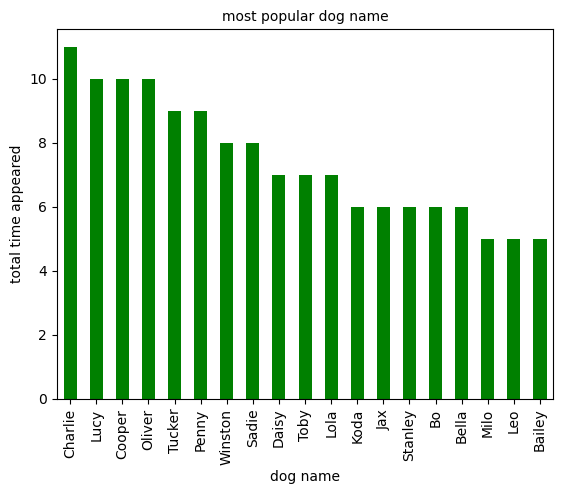

```python
popular_dog_name.plot.bar(color='green',fontsize='10')
plt.title('most popular dog name',color='black',fontsize='10')
plt.xlabel('dog name',color='black',fontsize='10')
plt.ylabel('total time appeared',color='black',fontsize='10')
```

QUESTION 2: What is the most popular dog stage?

```python
popular_dog_stage=twitter_archive_master.dog_stage.value_counts()
popular_dog_stage
```

```
pupper           201
doggo             63
puppo             22
doggo,pupper       8
floofer            7
doggo,puppo        1
doggo,floofer      1
Name: dog_stage, dtype: int64
```

Pupper is the most popular dog_stage

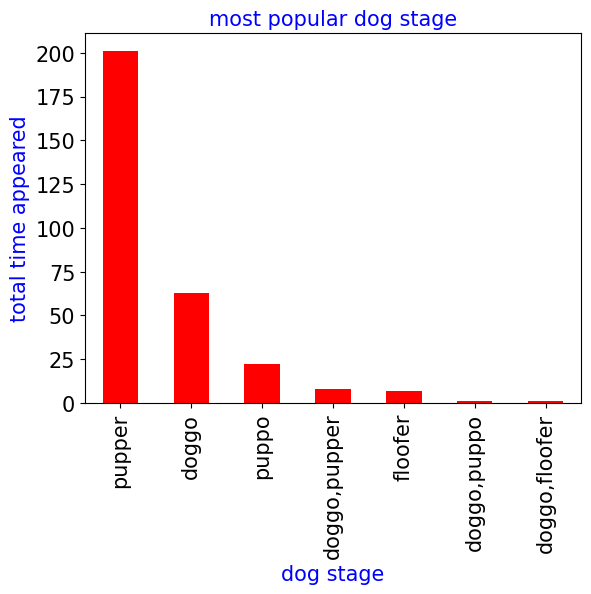

```python
popular_dog_stage.plot.bar(color='red',fontsize=15)
plt.title('most popular dog stage',color='blue',fontsize='15')
plt.xlabel('dog stage',color='blue',fontsize='15')
plt.ylabel('total time appeared',color='blue',fontsize='15')
```

QUESTION 3. Is there a correlation between retweet_count and favorite_count?

A scatter plot will be used to show the correlation between retweet_count and favorite_count

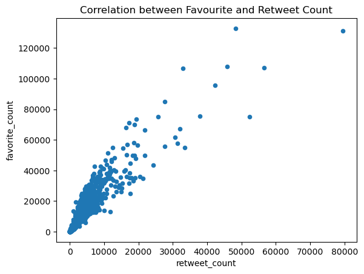

```python
twitter_archive_master.plot(x='retweet_count', y='favorite_count', kind='scatter',title='Correlation between Favourite and Retweet Count' )
```

As the retweet_count increase, favorite_count also increases which means they have a ositive correlation

QUESTION 4: Does the favorite count have any effect on rating.

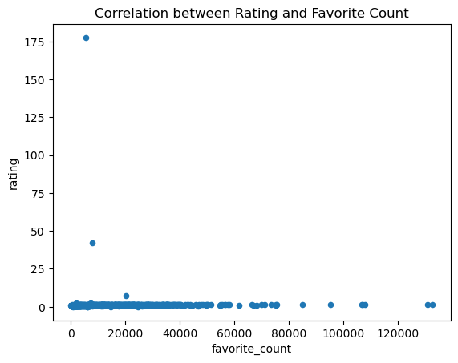

```python
twitter_archive_master.plot(x='favorite_count', y='rating', kind='scatter',title='Correlation between Rating and Favorite Count' )
```

From the above scatter plot, there was no correlation between favorite count and rating

QUESTION 5: Does retweet count have any effect on rating.

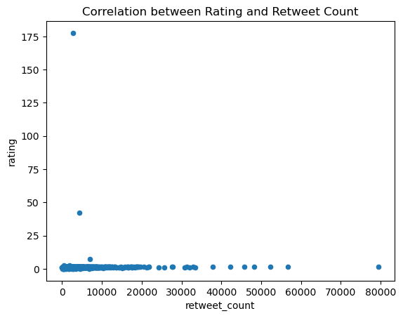

```python
twitter_archive_master.plot(x='retweet_count', y='rating', kind='scatter',title='Correlation between Rating and Retweet Count' )
```

There was no correlation between the two variabales.